# N1ACTIMAGERY_SPR_analyses

Constanze Weber

10/2024

This file documents statistical analyses reported in the talk **COMPARING SENSORY ATTENUATION IN ACTION EXECUTION, IMAGERY, AND OBSERVATION – A PREREGISTERED ERP STUDY**. 48 subjects participated in the study (of which 45 were included in the following analysis; three participants were excluded based on EEG data quality); each subject underwent a total of 100 trials of each motor-related sound condition as well as the cued external sound condition. The (uncued) external sound condition was administered twice such that each participant underwent a total of 200 trials of this condition (once at the beginning and once in the middle of the experiment). The motor-related sound conditions and the cued external sound conditions were once administered with sounds and once without (Control). As is standard in the contingent paradigm (Horvath, 2015), difference waves are constructed between these conditions (i.e. the corresponding sound and no-sound conditions). In the following script, amplitude data is analyzed that already underwent these aggregation steps.

R version 4.0.3 (2020-10-10), running under Windows 10 x64 (build 19044), was used to generate this document.

### Read and prepare data

```r
# read data
data <- read.csv("data_final.csv")

#### Data Preparation ####

# convert amplitudes in numeric variable
data$n1average <- as.numeric(data$n1average)
data$p2average <- as.numeric(data$p2average)

# add readable condition labels
data$condition_notes <- ifelse(data$condition == "actamc", "ACT Execution",
                               ifelse(data$condition == "imaamc", "ACT Imagery",
                                      ifelse(data$condition=="obsamc", "ACT Observation",
                                             ifelse(data$condition=="aoc", "EXT Uncued",
                                                    "EXT Cued"))))

# convert variable to factor
data$condition_effect <- as.factor(data$condition_notes)
# code contrast with reference level aoc (uncued external sounds)
contrasts(data$condition_effect) <- contr.treatment(5, base=5)
```

### N1 Analysis

```r
# linear mixed-effects model for n1 amplitude data
n1_model <- lmer(n1average ~ condition_effect +
                   (1 + condition_effect |id),
                 data=data, REML=T,
                 control = lmerControl(optimizer="bobyqa"))
summary(n1_model)
```

```
## Linear mixed model fit by REML. t-tests use Satterthwaite's method ['lmerModLmerTest']
## Formula: n1average ~ condition_effect + (1 + condition_effect | id)
##    Data: data
## Control: lmerControl(optimizer = "bobyqa")
##
## REML criterion at convergence: 195649.6
##
## Scaled residuals:
##      Min       1Q   Median       3Q      Max
## -5.34803 -0.62726 -0.00052  0.62082  7.60671
##
## Random effects:
##  Groups   Name              Variance Std.Dev. Corr
##  id       (Intercept)        6.1490  2.4797
##           condition_effect1  5.2949  2.3011   -0.508
##           condition_effect2  2.3407  1.5299   -0.363  0.455
##           condition_effect3  2.1871  1.4789   -0.420  0.493  0.486
##           condition_effect4  4.2049  2.0506   -0.559  0.346  0.332  0.451
##  Residual                   92.6563  9.6258
## Number of obs: 26511, groups:  id, 45
##
## Fixed effects:
##                   Estimate Std. Error       df  t value  Pr(>|t|)
## (Intercept)       -4.57020    0.38369 43.93542 -11.9110 2.379e-15 ***
## condition_effect1  1.46360    0.38630 43.89994   3.7887 0.0004573 ***
## condition_effect2  0.35288    0.28914 43.63381   1.2204 0.2288539
## condition_effect3  0.37194    0.28295 44.17778   1.3145 0.1954532
## condition_effect4  1.08431    0.35441 44.40473   3.0595 0.0037515 **
## ---
## Signif. codes:  0 '***' 0.001 '**' 0.01 '*' 0.05 '.' 0.1 ' ' 1
##
## Correlation of Fixed Effects:
##             (Intr) cndt_1 cndt_2 cndt_3
## cndtn_ffct1 -0.506
## cndtn_ffct2 -0.371  0.413
## cndtn_ffct3 -0.412  0.438  0.428
## cndtn_ffct4 -0.542  0.342  0.329  0.409
```

```r
# follow-up tests to compare attenuation magnitude between the motor-related
# conditions and cued external sounds condition
n1mmeans <- emmeans::emmeans(n1_model, ~ condition_effect, CIs = TRUE,
                             cov.reduce = range, lmer.df="asymp", adj="bonf", infer=T)
pairs(pairs(n1mmeans, simple = "condition_effect"), by = NULL, adj="none")
```

```
##  contrast                                                            estimate    SE  df z.ratio p.value
##  (ACT Execution - ACT Imagery) - (ACT Execution - ACT Observation)    0.01906 0.306 Inf   0.062  0.9503
##  (ACT Execution - ACT Imagery) - (ACT Execution - EXT Cued)           0.73144 0.377 Inf   1.942  0.0521
##  (ACT Execution - ACT Imagery) - (ACT Execution - EXT Uncued)        -0.35288 0.289 Inf  -1.220  0.2223
##  (ACT Execution - ACT Imagery) - (ACT Imagery - ACT Observation)      1.12978 0.579 Inf   1.952  0.0509
##  (ACT Execution - ACT Imagery) - (ACT Imagery - EXT Cued)             1.84216 0.619 Inf   2.974  0.0029
##  (ACT Execution - ACT Imagery) - (ACT Imagery - EXT Uncued)           0.75784 0.547 Inf   1.386  0.1658
##  (ACT Execution - ACT Imagery) - (ACT Observation - EXT Cued)         1.82309 0.515 Inf   3.542  0.0004
##  (ACT Execution - ACT Imagery) - (ACT Observation - EXT Uncued)       0.73878 0.441 Inf   1.674  0.0942
##  (ACT Execution - ACT Imagery) - (EXT Cued - EXT Uncued)              0.02641 0.490 Inf   0.054  0.9570
##  (ACT Execution - ACT Observation) - (ACT Execution - EXT Cued)       0.71237 0.352 Inf   2.025  0.0428
##  (ACT Execution - ACT Observation) - (ACT Execution - EXT Uncued)    -0.37194 0.283 Inf  -1.315  0.1887
##  (ACT Execution - ACT Observation) - (ACT Imagery - ACT Observation)  1.11072 0.375 Inf   2.963  0.0030
##  (ACT Execution - ACT Observation) - (ACT Imagery - EXT Cued)         1.82309 0.515 Inf   3.542  0.0004
##  (ACT Execution - ACT Observation) - (ACT Imagery - EXT Uncued)       0.73878 0.441 Inf   1.674  0.0942
##  (ACT Execution - ACT Observation) - (ACT Observation - EXT Cued)     1.80403 0.577 Inf   3.124  0.0018
##  (ACT Execution - ACT Observation) - (ACT Observation - EXT Uncued)   0.71972 0.527 Inf   1.365  0.1723
##  (ACT Execution - ACT Observation) - (EXT Cued - EXT Uncued)          0.00734 0.497 Inf   0.015  0.9882
##  (ACT Execution - EXT Cued) - (ACT Execution - EXT Uncued)           -1.08431 0.354 Inf  -3.060  0.0022
##  (ACT Execution - EXT Cued) - (ACT Imagery - ACT Observation)         0.39835 0.513 Inf   0.776  0.4378
##  (ACT Execution - EXT Cued) - (ACT Imagery - EXT Cued)                1.11072 0.375 Inf   2.963  0.0030
##  (ACT Execution - EXT Cued) - (ACT Imagery - EXT Uncued)              0.02641 0.490 Inf   0.054  0.9570
##  (ACT Execution - EXT Cued) - (ACT Observation - EXT Cued)            1.09166 0.365 Inf   2.987  0.0028
##  (ACT Execution - EXT Cued) - (ACT Observation - EXT Uncued)          0.00734 0.497 Inf   0.015  0.9882
##  (ACT Execution - EXT Cued) - (EXT Cued - EXT Uncued)                -0.70503 0.681 Inf  -1.035  0.3007
##  (ACT Execution - EXT Uncued) - (ACT Imagery - ACT Observation)       1.48266 0.496 Inf   2.987  0.0028
##  (ACT Execution - EXT Uncued) - (ACT Imagery - EXT Cued)              2.19504 0.541 Inf   4.058  <.0001
##  (ACT Execution - EXT Uncued) - (ACT Imagery - EXT Uncued)            1.11072 0.375 Inf   2.963  0.0030
##  (ACT Execution - EXT Uncued) - (ACT Observation - EXT Cued)          2.17597 0.521 Inf   4.180  <.0001
##  (ACT Execution - EXT Uncued) - (ACT Observation - EXT Uncued)        1.09166 0.365 Inf   2.987  0.0028
##  (ACT Execution - EXT Uncued) - (EXT Cued - EXT Uncued)               0.37928 0.426 Inf   0.891  0.3728
##  (ACT Imagery - ACT Observation) - (ACT Imagery - EXT Cued)           0.71237 0.352 Inf   2.025  0.0428
##  (ACT Imagery - ACT Observation) - (ACT Imagery - EXT Uncued)        -0.37194 0.283 Inf  -1.315  0.1887
##  (ACT Imagery - ACT Observation) - (ACT Observation - EXT Cued)       0.69331 0.541 Inf   1.281  0.2002
##  (ACT Imagery - ACT Observation) - (ACT Observation - EXT Uncued)    -0.39100 0.514 Inf  -0.761  0.4465
##  (ACT Imagery - ACT Observation) - (EXT Cued - EXT Uncued)           -1.10338 0.484 Inf  -2.282  0.0225
##  (ACT Imagery - EXT Cued) - (ACT Imagery - EXT Uncued)               -1.08431 0.354 Inf  -3.060  0.0022
##  (ACT Imagery - EXT Cued) - (ACT Observation - EXT Cued)             -0.01906 0.306 Inf  -0.062  0.9503
##  (ACT Imagery - EXT Cued) - (ACT Observation - EXT Uncued)           -1.10338 0.484 Inf  -2.282  0.0225
##  (ACT Imagery - EXT Cued) - (EXT Cued - EXT Uncued)                  -1.81575 0.672 Inf  -2.703  0.0069
##  (ACT Imagery - EXT Uncued) - (ACT Observation - EXT Cued)            1.06525 0.452 Inf   2.355  0.0185
##  (ACT Imagery - EXT Uncued) - (ACT Observation - EXT Uncued)         -0.01906 0.306 Inf  -0.062  0.9503
##  (ACT Imagery - EXT Uncued) - (EXT Cued - EXT Uncued)                -0.73144 0.377 Inf  -1.942  0.0521
##  (ACT Observation - EXT Cued) - (ACT Observation - EXT Uncued)       -1.08431 0.354 Inf  -3.060  0.0022
##  (ACT Observation - EXT Cued) - (EXT Cued - EXT Uncued)              -1.79669 0.647 Inf  -2.777  0.0055
##  (ACT Observation - EXT Uncued) - (EXT Cued - EXT Uncued)            -0.71237 0.352 Inf  -2.025  0.0428
##
## Degrees-of-freedom method: asymptotic
```

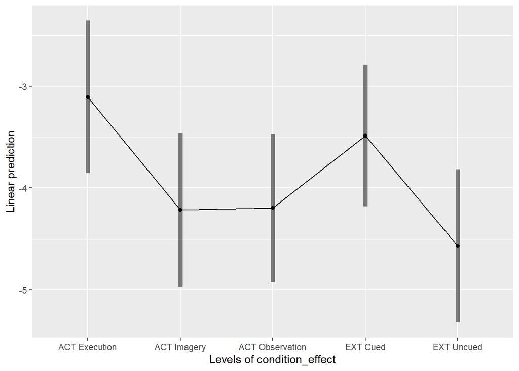

```r
# basic plot for first visualization
emmeans::emmip(n1_model, ~ condition_effect, CIs = TRUE, cov.reduce = range,
               lmer.df="asymp", style="factor")
```

```r
#### Create plot (matching colours of grand average plot) ####

# Using ggpredict to create predicted values with confidence intervals for the
# effect of condition
plotdata <- ggeffects::ggpredict(n1_model, terms = "condition_effect")
plotdata <- as.data.frame(plotdata) # convert to data frame
print(head(plotdata))
```

```
##                 x  predicted  std.error   conf.low  conf.high group
## 1   ACT Execution -3.1065982 0.38369443 -3.8586254 -2.3545709     1
## 2     ACT Imagery -4.2173184 0.38286454 -4.9677191 -3.4669176     1
## 3 ACT Observation -4.1982570 0.38527025 -4.9533728 -3.4431412     1
## 4        EXT Cued -3.4858828 0.37110174 -4.2132289 -2.7585368     1
## 5      EXT Uncued -4.5701976 0.35411538 -5.2642510 -3.8761442     1
```

```r
# define colors
point_colors <- 3:7

# open PNG
png(filename = "plots/N1_condition_effect_color.png", width = 5.5, height = 4, units = "in", res = 400)
par(mgp=c(1.95,.65,0.65))

plot(1:length(plotdata$x), plotdata$predicted,
     type = "p", col = point_colors, pch = 16, xlab = "", ylab = expression("Predicted N1 amplitudes in "* mu*V),
     ylim = c(-2,-6), yaxt = "n", xaxt = "n", main = "", bty = "n")

# add x-axis
axis(1, at = 1:length(plotdata$x),
     labels = c(" \n Execution", " \n Imagery", " \n Observation", "Cued\n Sound",
                "Sound-\n Only"), col.axis = "black",
     mgp=c(0,1.5,.25))

# adding error bars for confidence intervals
for (i in 1:length(plotdata$x)) {
  arrows(i, plotdata$conf.low[i],
         i, plotdata$conf.high[i],
         angle = 90, code = 3, length = 0.1, col = point_colors[i])
}

# add y-axis
axis(2, at = seq(-6, -2, by = 1), las = 1, col.axis = "black")

# add some dotted lines for orientation
abline(h = seq(-6, -2, by = 0.5), col = "gray", lty = "dotted")

# Close PNG device
dev.off()
```

```r
#### Create plot (matching colours of grand average plot) WITHOUT CUE ####

# Using ggpredict to create predicted values with confidence intervals for the
# effect of condition
plotdata <- ggeffects::ggpredict(n1_model, terms = "condition_effect")
plotdata <- as.data.frame(plotdata) # convert to data frame
plotdata <- plotdata[-4,]
print(plotdata)
```

```
##                 x  predicted  std.error   conf.low  conf.high group
## 1   ACT Execution -3.1065982 0.38369443 -3.8586254 -2.3545709     1
## 2     ACT Imagery -4.2173184 0.38286454 -4.9677191 -3.4669176     1
## 3 ACT Observation -4.1982570 0.38527025 -4.9533728 -3.4431412     1
## 5      EXT Uncued -4.5701976 0.35411538 -5.2642510 -3.8761442     1
```

```r
# define colors
point_colors <- c(3:5,7)

# open PNG
png(filename = "plots/N1_condition_effect_color_without_cue.png", width = 5.5, height = 4, units = "in", res = 400)
par(mgp=c(1.95,.65,0.65))

plot(1:4, plotdata$predicted,
     type = "p", col = point_colors, pch = 16, xlab = "", ylab = expression("Predicted N1 amplitudes in "* mu*V),
     ylim = c(-2,-6), yaxt = "n", xaxt = "n", main = "", bty = "n")

# add x-axis
axis(1, at = 1:4,
     labels =c(" \n Execution", " \n Imagery", " \n Observation",
               "Sound-\n Only"), col.axis = "black",
     mgp=c(0,1.5,.25))

# adding error bars for confidence intervals
for (i in 1:4) {
  arrows(i, plotdata$conf.low[i],
         i, plotdata$conf.high[i],
         angle = 90, code = 3, length = 0.1, col = point_colors[i])
}

# add y-axis
axis(2, at = seq(-6, -2, by = 1), las = 1, col.axis = "black")

# add some dotted lines for orientation
abline(h = seq(-6, -2, by = 0.5), col = "gray", lty = "dotted")

# Close PNG device
dev.off()
```

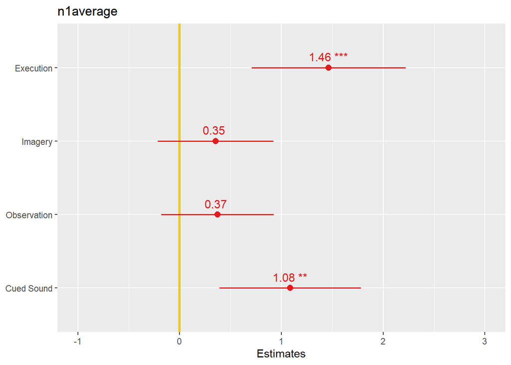

[figure not shown]

```r
#### Create plot to visualize differences in attenuation magnitude (quick and dirty)
sjPlot::plot_model(n1_model, vline.color = 7, show.values = TRUE,
                 axis.labels=rev(c("Execution", "Imagery", "Observation", "Cued Sound")))
```

### P2 Analysis

```r
# linear mixed-effects model for P2 amplitude data
p2_model <- lmer(p2average ~ condition_effect +
                   (1 + condition_effect |id),
                 data=data, REML=T,
                 control = lmerControl(optimizer="bobyqa"))
summary(p2_model)
```

```
## Linear mixed model fit by REML. t-tests use Satterthwaite's method ['lmerModLmerTest']
## Formula: p2average ~ condition_effect + (1 + condition_effect | id)
##    Data: data
## Control: lmerControl(optimizer = "bobyqa")
##
## REML criterion at convergence: 198753.5
##
## Scaled residuals:
##      Min       1Q   Median       3Q      Max
## -6.09264 -0.62065  0.00114  0.63146  5.43018
##
## Random effects:
##  Groups   Name              Variance Std.Dev. Corr
##  id       (Intercept)        10.1901  3.1922
##           condition_effect1   7.6388  2.7638  -0.603
##           condition_effect2   4.4240  2.1033  -0.730  0.608
##           condition_effect3   4.7422  2.1777  -0.677  0.628  0.697
##           condition_effect4   5.1192  2.2626  -0.730  0.438  0.816  0.679
##  Residual                   104.1581 10.2058
## Number of obs: 26511, groups:  id, 45
##
## Fixed effects:
##                   Estimate Std. Error       df t value  Pr(>|t|)
## (Intercept)        4.55223    0.48822 43.76503  9.3242 5.820e-12 ***
## condition_effect1 -3.22316    0.45305 44.15881 -7.1144 7.626e-09 ***
## condition_effect2 -2.07721    0.36583 43.65010 -5.6781 1.025e-06 ***
## condition_effect3 -2.47688    0.37519 43.11152 -6.6016 4.815e-08 ***
## condition_effect4 -1.38514    0.38707 42.42368 -3.5785 0.0008808 ***
## ---
## Signif. codes:  0 '***' 0.001 '**' 0.01 '*' 0.05 '.' 0.1 ' ' 1
##
## Correlation of Fixed Effects:
##             (Intr) cndt_1 cndt_2 cndt_3
## cndtn_ffct1 -0.588
## cndtn_ffct2 -0.677  0.545
## cndtn_ffct3 -0.636  0.564  0.604
## cndtn_ffct4 -0.683  0.415  0.693  0.594
```

```r
# follow-up tests to compare attenuation between conditions
p2mmeans <- emmeans::emmeans(p2_model, ~ condition_effect, CIs = TRUE,
                             cov.reduce = range, lmer.df="asymp", adj="bonf", infer=T)
pairs(pairs(p2mmeans, simple = "condition_effect"), by = NULL, adj="none")
```

```
##  contrast                                                            estimate    SE  df z.ratio p.value
##  (ACT Execution - ACT Imagery) - (ACT Execution - ACT Observation)    -0.3997 0.330 Inf  -1.212  0.2257
##  (ACT Execution - ACT Imagery) - (ACT Execution - EXT Cued)            0.6921 0.295 Inf   2.342  0.0192
##  (ACT Execution - ACT Imagery) - (ACT Execution - EXT Uncued)          2.0772 0.366 Inf   5.678  <.0001
##  (ACT Execution - ACT Imagery) - (ACT Imagery - ACT Observation)      -1.5456 0.616 Inf  -2.507  0.0122
##  (ACT Execution - ACT Imagery) - (ACT Imagery - EXT Cued)             -0.4539 0.531 Inf  -0.855  0.3923
##  (ACT Execution - ACT Imagery) - (ACT Imagery - EXT Uncued)            0.9313 0.616 Inf   1.513  0.1303
##  (ACT Execution - ACT Imagery) - (ACT Observation - EXT Cued)         -0.0542 0.447 Inf  -0.121  0.9034
##  (ACT Execution - ACT Imagery) - (ACT Observation - EXT Uncued)        1.3309 0.522 Inf   2.548  0.0108
##  (ACT Execution - ACT Imagery) - (EXT Cued - EXT Uncued)               0.2392 0.599 Inf   0.399  0.6898
##  (ACT Execution - ACT Observation) - (ACT Execution - EXT Cued)        1.0917 0.344 Inf   3.175  0.0015
##  (ACT Execution - ACT Observation) - (ACT Execution - EXT Uncued)      2.4769 0.375 Inf   6.602  <.0001
##  (ACT Execution - ACT Observation) - (ACT Imagery - ACT Observation)  -1.1460 0.398 Inf  -2.881  0.0040
##  (ACT Execution - ACT Observation) - (ACT Imagery - EXT Cued)         -0.0542 0.447 Inf  -0.121  0.9034
##  (ACT Execution - ACT Observation) - (ACT Imagery - EXT Uncued)        1.3309 0.522 Inf   2.548  0.0108
##  (ACT Execution - ACT Observation) - (ACT Observation - EXT Cued)      0.3455 0.579 Inf   0.597  0.5506
##  (ACT Execution - ACT Observation) - (ACT Observation - EXT Uncued)    1.7306 0.620 Inf   2.791  0.0053
##  (ACT Execution - ACT Observation) - (EXT Cued - EXT Uncued)           0.6389 0.575 Inf   1.111  0.2668
##  (ACT Execution - EXT Cued) - (ACT Execution - EXT Uncued)             1.3851 0.387 Inf   3.579  0.0003
##  (ACT Execution - EXT Cued) - (ACT Imagery - ACT Observation)         -2.2377 0.595 Inf  -3.763  0.0002
##  (ACT Execution - EXT Cued) - (ACT Imagery - EXT Cued)                -1.1460 0.398 Inf  -2.881  0.0040
##  (ACT Execution - EXT Cued) - (ACT Imagery - EXT Uncued)               0.2392 0.599 Inf   0.399  0.6898
##  (ACT Execution - EXT Cued) - (ACT Observation - EXT Cued)            -0.7463 0.393 Inf  -1.901  0.0573
##  (ACT Execution - EXT Cued) - (ACT Observation - EXT Uncued)           0.6389 0.575 Inf   1.111  0.2668
##  (ACT Execution - EXT Cued) - (EXT Cued - EXT Uncued)                 -0.4529 0.717 Inf  -0.632  0.5275
##  (ACT Execution - EXT Uncued) - (ACT Imagery - ACT Observation)       -3.6228 0.570 Inf  -6.353  <.0001
##  (ACT Execution - EXT Uncued) - (ACT Imagery - EXT Cued)              -2.5311 0.507 Inf  -4.991  <.0001
##  (ACT Execution - EXT Uncued) - (ACT Imagery - EXT Uncued)            -1.1460 0.398 Inf  -2.881  0.0040
##  (ACT Execution - EXT Uncued) - (ACT Observation - EXT Cued)          -2.1314 0.526 Inf  -4.050  0.0001
##  (ACT Execution - EXT Uncued) - (ACT Observation - EXT Uncued)        -0.7463 0.393 Inf  -1.901  0.0573
##  (ACT Execution - EXT Uncued) - (EXT Cued - EXT Uncued)               -1.8380 0.458 Inf  -4.014  0.0001
##  (ACT Imagery - ACT Observation) - (ACT Imagery - EXT Cued)            1.0917 0.344 Inf   3.175  0.0015
##  (ACT Imagery - ACT Observation) - (ACT Imagery - EXT Uncued)          2.4769 0.375 Inf   6.602  <.0001
##  (ACT Imagery - ACT Observation) - (ACT Observation - EXT Cued)        1.4914 0.606 Inf   2.463  0.0138
##  (ACT Imagery - ACT Observation) - (ACT Observation - EXT Uncued)      2.8766 0.604 Inf   4.759  <.0001
##  (ACT Imagery - ACT Observation) - (EXT Cued - EXT Uncued)             1.7848 0.484 Inf   3.684  0.0002
##  (ACT Imagery - EXT Cued) - (ACT Imagery - EXT Uncued)                 1.3851 0.387 Inf   3.579  0.0003
##  (ACT Imagery - EXT Cued) - (ACT Observation - EXT Cued)               0.3997 0.330 Inf   1.212  0.2257
##  (ACT Imagery - EXT Cued) - (ACT Observation - EXT Uncued)             1.7848 0.484 Inf   3.684  0.0002
##  (ACT Imagery - EXT Cued) - (EXT Cued - EXT Uncued)                    0.6931 0.583 Inf   1.188  0.2349
##  (ACT Imagery - EXT Uncued) - (ACT Observation - EXT Cued)            -0.9855 0.532 Inf  -1.854  0.0638
##  (ACT Imagery - EXT Uncued) - (ACT Observation - EXT Uncued)           0.3997 0.330 Inf   1.212  0.2257
##  (ACT Imagery - EXT Uncued) - (EXT Cued - EXT Uncued)                 -0.6921 0.295 Inf  -2.342  0.0192
##  (ACT Observation - EXT Cued) - (ACT Observation - EXT Uncued)         1.3851 0.387 Inf   3.579  0.0003
##  (ACT Observation - EXT Cued) - (EXT Cued - EXT Uncued)                0.2934 0.629 Inf   0.467  0.6407
##  (ACT Observation - EXT Uncued) - (EXT Cued - EXT Uncued)             -1.0917 0.344 Inf  -3.175  0.0015
##
## Degrees-of-freedom method: asymptotic
```

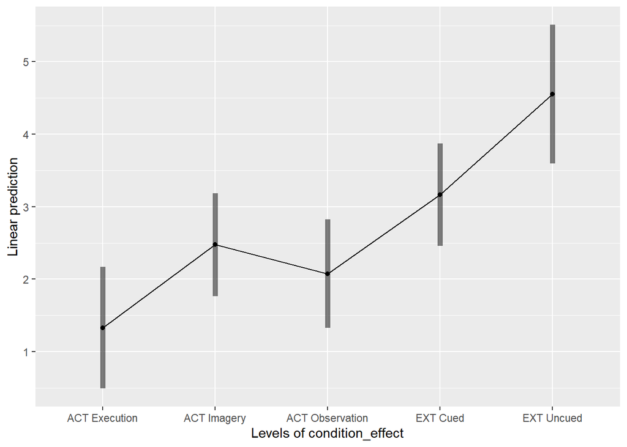

```r
# basic plot for first visualization
emmeans::emmip(p2_model, ~ condition_effect, CIs = TRUE, cov.reduce = range,
               lmer.df="asymp", style="factor")
```

```r
#### Create P2 Plot ####

# Using ggpredict to create predicted values with confidence intervals for the
# effect of condition
plotdata <- ggeffects::ggpredict(p2_model, terms = "condition_effect")
plotdata <- as.data.frame(plotdata)

# define colors
point_colors <- 3:7

# open png
png(filename = "plots/P2_condition_effect_color.png", width = 5.5, height = 4, units = "in", res = 400)
par(mgp=c(1.95,.65,0.65))

plot(1:length(plotdata$x), plotdata$predicted,
     type = "p", col = point_colors, pch = 16, xlab = "", ylab = expression("Predicted P2 amplitudes in "* mu*V),
     ylim = c(6,0), yaxt = "n", xaxt = "n",  main = "", bty = "n")

# add x-axis
axis(1, at = 1:length(plotdata$x),
     labels =c(" \n Execution", " \n Imagery", " \n Observation", "Cued\n Sound",
                "Sound-\n Only"), col.axis = "black",
     mgp=c(0,1.5,.25))

# adding error bars for confidence intervals
for (i in 1:length(plotdata$x)) {
  arrows(i, plotdata$conf.low[i],
         i, plotdata$conf.high[i],
         angle = 90, code = 3, length = 0.1, col = point_colors[i])
}

# add y-axis
axis(2, at = seq(0,6, by = 1), las = 1, col.axis = "black")

# add dotted lines for orientation
abline(h = seq(0, 6, by = 1), col = "gray", lty = "dotted")

# close device
dev.off()
```

```r
#### Create P2 Plot without cue condition ####

# Using ggpredict to create predicted values with confidence intervals for the
# effect of condition
plotdata <- ggeffects::ggpredict(p2_model, terms = "condition_effect")
plotdata <- as.data.frame(plotdata)
plotdata <- plotdata[-4,]
print(plotdata)
```

```
##                 x predicted  std.error   conf.low conf.high group
## 1   ACT Execution 1.3290690 0.48821586 0.37218347 2.2859545     1
## 2     ACT Imagery 2.4750221 0.42817936 1.63580600 3.3142383     1
## 3 ACT Observation 2.0753490 0.36116234 1.36748384 2.7832142     1
## 5      EXT Uncued 4.5522272 0.36052724 3.84560677 5.2588476     1
```

[figure not shown]

```r
# define colors
point_colors <- c(3:5,7)

# open png
png(filename = "plots/P2_condition_effect_color_without_cue.png", width = 5.5, height = 4, units = "in", res = 400)
par(mgp=c(1.95,.65,0.65))

plot(1:4, plotdata$predicted,
     type = "p", col = point_colors, pch = 16, xlab = "", ylab = expression("Predicted P2 amplitudes in "* mu*V),
     ylim = c(6,0), yaxt = "n", xaxt = "n",  main = "", bty = "n")

# add x-axis
axis(1, at = 1:4,
     labels = c(" \n Execution", " \n Imagery", " \n Observation", "Sound-\n Only"), col.axis = "black",
     mgp=c(0,1.5,.25))

# adding error bars for confidence intervals
for (i in 1:4) {
  arrows(i, plotdata$conf.low[i],
         i, plotdata$conf.high[i],
         angle = 90, code = 3, length = 0.1, col = point_colors[i])
}

# add y-axis
axis(2, at = seq(0,6, by = 1), las = 1, col.axis = "black")

# add dotted lines for orientation
abline(h = seq(0, 6, by = 1), col = "gray", lty = "dotted")

# close device
dev.off()
```